# Digitalis Dataset

# Research question

**Population:** Patients taking digoxin prior to randomization

**Exposure:** Discontinuation of digoxin as per randomization

**Outcome:** Short-term (12 months) risk / hazard ratio of death due to worsened heart failure.

# Data cleaning

## Removal of unrelated variables and outcomes

I have not included the columns mentioned below in any of the following analyses:

```
 [1] "ejfmeth"  "digdoser" "rales"    "elevjvp"  "pedema"   "restdys"
 [7] "exertdys" "actlimit" "s3"       "pulcong"  "nsym"     "heartrte"
[13] "diabp"    "sysbp"    "angina"   "diguse"   "digdose"  "cvd"
[19] "cvddays"  "whf"      "whfdays"  "dig"      "digdays"  "uang"
[25] "uangdays" "strk"     "strkdays" "sva"      "svadays"  "vena"
[31] "venadays" "crev"     "crevdays" "ocvd"     "ocvddays" "rinf"
[37] "rinfdays" "oth"      "othdays"  "hosp"     "hospdays" "nhosp"
[43] "dwhf"     "dwhfdays"
```

Should we include any of those?

## Missing values

### Categorical variables

Some of the categorical variables have missing values. I have dropped the observations with missing values for the variables that are included in the final model.

For the “reason” variable, the missing values means that the patients were still alive. I have recoded it as such.

### Continuos variables

klevel and chfdur have missing values. As they are not included in the final model I will leave those observations as is.

## Censoring

As we only look at short-term mortality we need to right censor our data, meaning that patients with an event after 365 days will be recoded to not having an event. Additionally, any observational days > 365 will be recoded to 365.

Checking the censoring on a random sample of 100 observations:

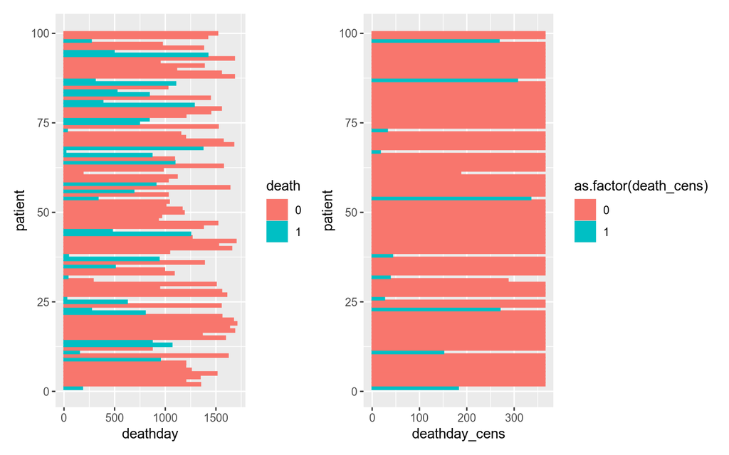

# Modeling

## Informative censoring?

I created a variable called “dropout” to indicate if a patient was censored at < 365.

| trtmt | n |
| --- | --- |
| Continued Digoxin | 12 |
| Discontinued Digoxin | 6 |

## Categorical predictors

### chfetiol

I have recoded this to follow the primary paper with ischemic vs non-ischemic.

### functcls

The counts for class IV are very sparse causing the coefficients in the cox PH model to become very unstable. I have recoded the variable to binary as in the primary paper: class I+II vs class III + IV

## Numerical predictors

### Correlation matrix

| term | age | ejf_per | chestx | bmi | klevel | creat | chfdur |
| --- | --- | --- | --- | --- | --- | --- | --- |
| age | NA | NA | NA | NA | NA | NA | NA |
| ejf_per | 0.0082 | NA | NA | NA | NA | NA | NA |
| chestx | 0.0205 | -0.2151 | NA | NA | NA | NA | NA |
| bmi | 0.0376 | -0.0214 | -0.0338 | NA | NA | NA | NA |
| klevel | 0.0080 | -0.0012 | -0.0071 | -0.0033 | NA | NA | NA |
| creat | -0.0270 | -0.0045 | -0.0259 | -0.0332 | -0.0111 | NA | NA |
| chfdur | 0.0309 | -0.0034 | -0.0154 | 0.0134 | 0.0064 | 0.037 | NA |

Seems we shouldnt be too concerned with collinear variables for the numerical predictors.

### Checking linearity assumption

We can check the linearity of the individual variables by fitting a model where the only term is a penalized spline of a given variable. We can then use that model to predict the HRs for the observed values and plot the results to check for linearity. Please note that the splines become unstable when the no. of observations are low, which is the case for the lower and upper tail for most of the variables.

### Age

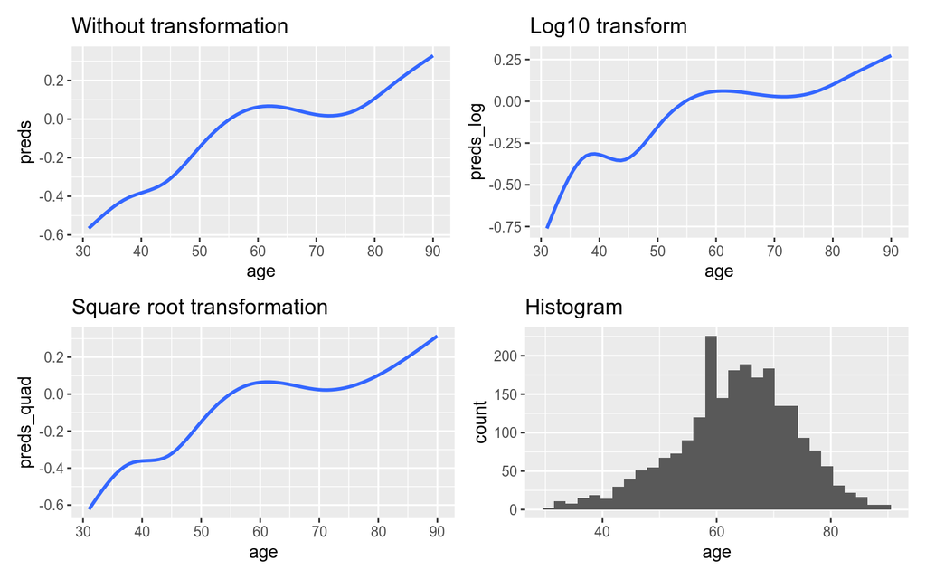

I have converted to age groups of 20 years (i.e: 20-40, 40-60 etc.)

### Ejection fraction

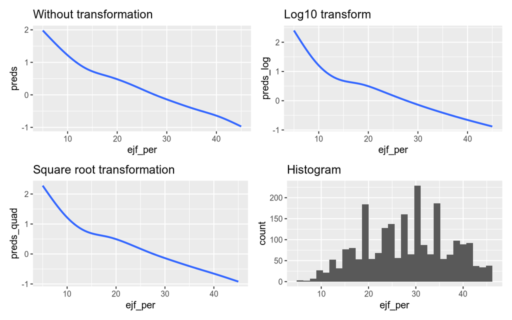

Seems like there is an approximately linear relationship between ejection fraction and HR. Will keep as continuous variable.

### BMI

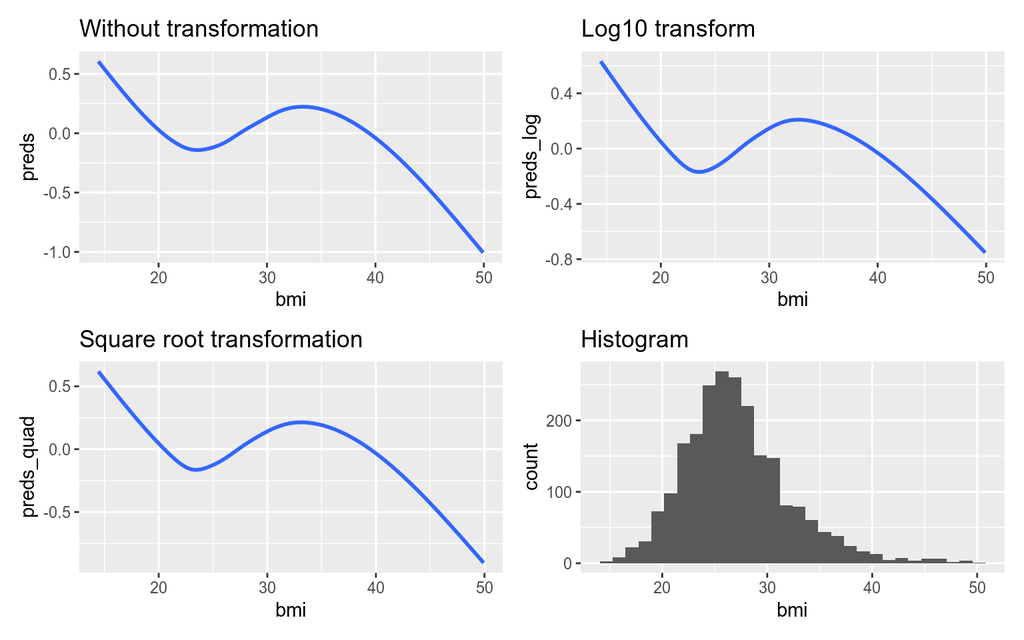

Seems that BMI is non-linear. Transformed to following scale: < 18.5 = underweight 18.5 -24.9 = normal 25-29.9 = overweight > 30 = obese

### Klevel

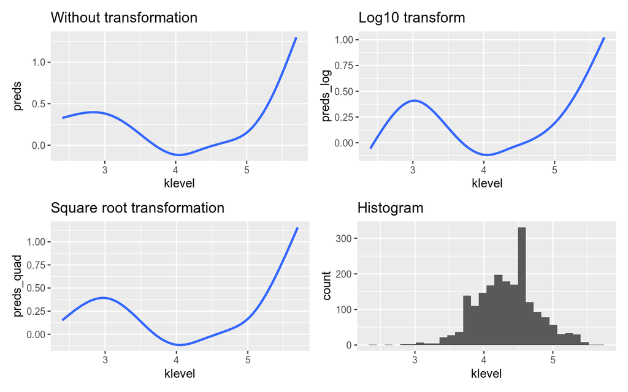

Recoded as categorical: < 3.5 = “low” 3.5 - 5.1 = “normal” > 5.1 = “high”

### Creat

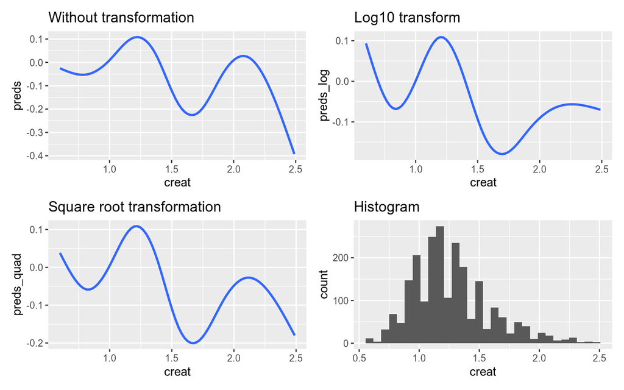

I have recoded as categorical based on the following intervals:

For men, 0.74 to 1.35 mg/dL For women, 0.59 to 1.04 mg/dL

### CHF duration

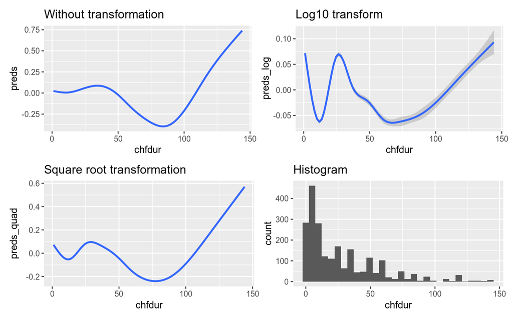

Recoding as > 60 months vs <= 60 months

### Chestx

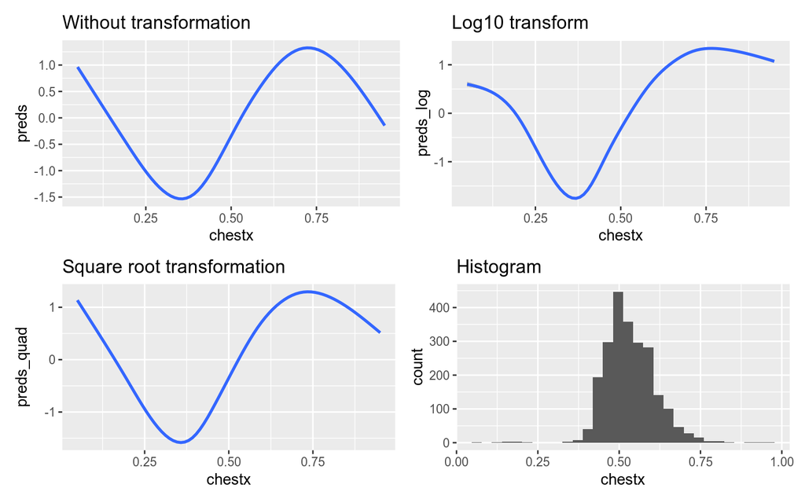

I have recoded as categorical as defined in the primary study: <= 0.55 vs > 0.55

Ilan: A patient had a cardiothoracic ratio of 0.05. Is that possible or an error?

### Time dependant covariates

I initially added MI events as a time dependant variable but the number of events were too few making the estimate very unstable. Would have been nice to have included a time dependant covariate as we then would not have to worry about the proportional hazards assumption.

## Table 1

| **Characteristic** | **Continued Digoxin**, N = 1,116<sup>1</sup> | **Discontinued Digoxin**, N = 1,164<sup>1</sup> | **p-value**<sup>2</sup> |
| --- | --- | --- | --- |
| calculated: age at randomization | 64 (57, 71) | 65 (57, 70) | 0.9 |
| race |  |  | 0.3 |
| white | 955 (86%) | 979 (84%) |  |
| non-white | 161 (14%) | 185 (16%) |  |
| sex |  |  | 0.4 |
| male | 834 (75%) | 888 (76%) |  |
| female | 282 (25%) | 276 (24%) |  |
| q3: ejection fraction (percent) | 29 (22, 35) | 28 (20, 35) | 0.12 |
| q6: chest x-ray (ct-ratio) | 0.53 (0.49, 0.58) | 0.53 (0.49, 0.58) | 0.4 |
| calculated: body mass index (kg/m*m) | 26.4 (23.6, 29.3) | 26.5 (24.0, 30.0) | 0.11 |
| q9a: serum potassium level | 4.30 (4.00, 4.60) | 4.30 (4.00, 4.60) | 0.5 |
| Unknown | 126 | 146 |  |
| q9: serum creatinine (mg/dl) | 1.21 (1.04, 1.47) | 1.21 (1.04, 1.44) | >0.9 |
| q12: duration of chf (months) | 16 (5, 42) | 17 (5, 42) | 0.9 |
| Unknown | 3 | 1 |  |
| functcls |  |  | 0.4 |
| Class I | 158 (14%) | 160 (14%) |  |
| Class II | 583 (52%) | 633 (54%) |  |
| Class III | 346 (31%) | 352 (30%) |  |
| Class IV | 29 (2.6%) | 19 (1.6%) |  |
| chfetiol |  |  | 0.033 |
| Ischemic | 765 (69%) | 790 (68%) |  |
| Hypertensive | 85 (7.6%) | 115 (9.9%) |  |
| Valvular | 19 (1.7%) | 18 (1.5%) |  |
| Idiopathic | 190 (17%) | 183 (16%) |  |
| Alcohol related | 36 (3.2%) | 50 (4.3%) |  |
| Other | 21 (1.9%) | 8 (0.7%) |  |
| prevmi |  |  | 0.7 |
| 0 | 381 (34%) | 388 (33%) |  |
| 1 | 734 (66%) | 776 (67%) |  |

[output cut: 64 more lines]

<sup>*1*</sup> Median (IQR); n (%) <sup>*2*</sup> Wilcoxon rank sum test; Pearson's Chi-squared test

## Kaplan-Meier Curve

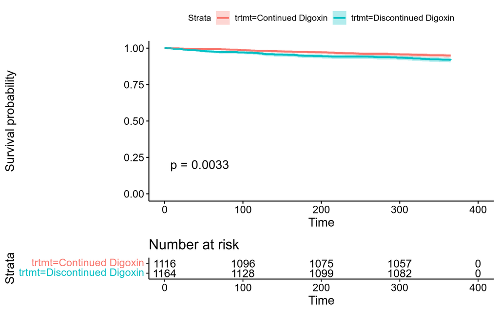

# Cox PH

## Simple model

| **Characteristic** | **HR**<sup>1</sup> | **95% CI**<sup>1</sup> | **p-value** |
| --- | --- | --- | --- |
| trtmt |  |  |  |
| Continued Digoxin | — | — |  |
| Discontinued Digoxin | 1.63 | 1.17, 2.28 | 0.004 |

<sup>*1*</sup> HR = Hazard Ratio, CI = Confidence Interval

## Adjusted Model

I primarily used AIC to guide variable selection, and ended up with the following model.

We can see that when adjusting the model for covariates related to race and CHF severity the HR for the discontinued digoxin group is still significantly increased.

| **Characteristic** | **HR**<sup>1</sup> | **95% CI**<sup>1</sup> | **p-value** |
| --- | --- | --- | --- |
| trtmt |  |  |  |
| Continued Digoxin | — | — |  |
| Discontinued Digoxin | 1.70 | 1.22, 2.37 | 0.002 |
| race |  |  |  |
| white | — | — |  |
| non-white | 0.74 | 0.47, 1.16 | 0.2 |
| q3: ejection fraction (percent) | 0.96 | 0.94, 0.98 | <0.001 |
| chestx_cat |  |  |  |
| <= 0.55 | — | — |  |
| > 0.55 | 2.30 | 1.62, 3.27 | <0.001 |
| functcls_bin |  |  |  |
| Class I/II | — | — |  |
| Class III/IV | 2.51 | 1.79, 3.52 | <0.001 |
| hydral |  |  |  |
| 0 | — | — |  |
| 1 | 2.71 | 1.37, 5.36 | 0.004 |

<sup>*1*</sup> HR = Hazard Ratio, CI = Confidence Interval

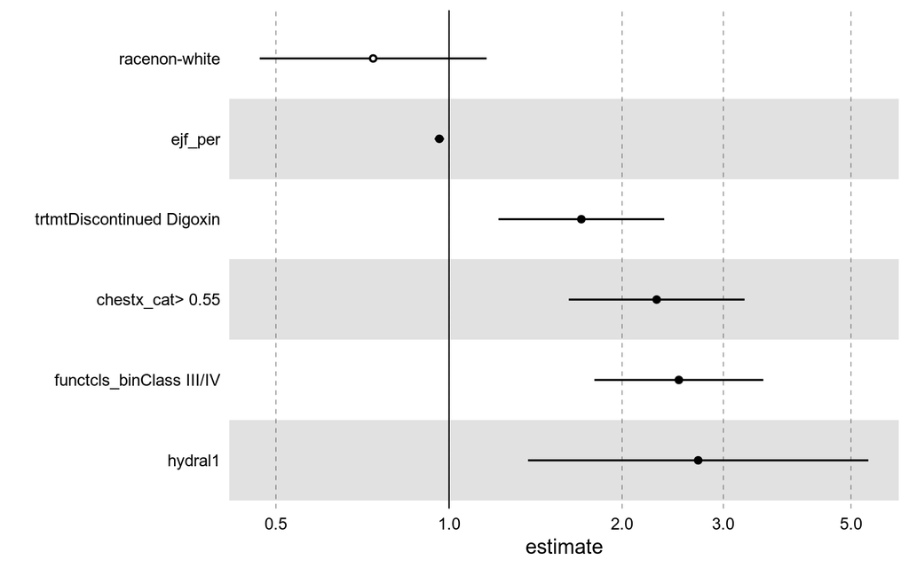

# Model Diagnostics

## Goodness of fit

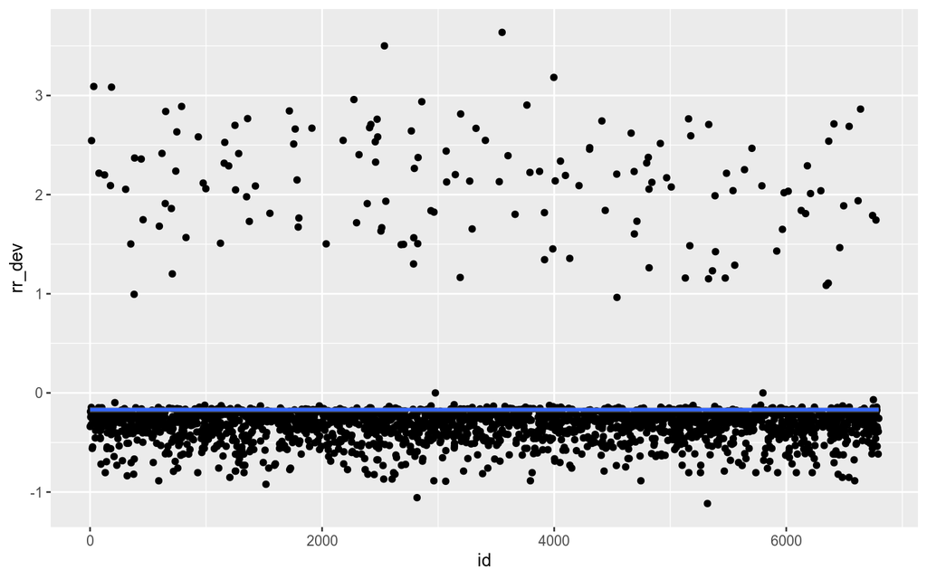

The deviance residuals do not raise any suspicions of a poor model fit.

## PH assumption

Based on the log(-log) plot and the tests for the Schoenfeld residuals of the final model, we can see that HRs are approximately proportional.

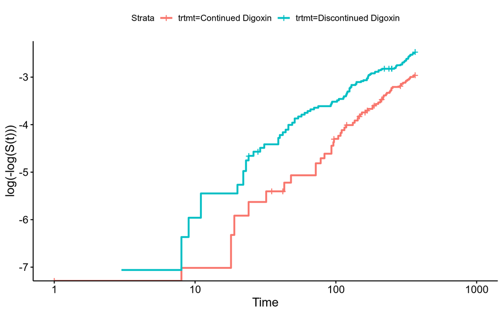

### Schoenfeld residual test

```
              chisq df    p
trtmt        1.2979  1 0.25
race         0.9181  1 0.34
ejf_per      2.1618  1 0.14
chestx_cat   1.5805  1 0.21
functcls_bin 0.0466  1 0.83
hydral       0.0673  1 0.80
GLOBAL       6.8801  6 0.33
```

# MODEL AFTER COMMENTS FROM ILAN

| **Characteristic** | **HR**<sup>1</sup> | **95% CI**<sup>1</sup> | **p-value** |
| --- | --- | --- | --- |
| trtmt |  |  |  |
| Continued Digoxin | — | — |  |
| Discontinued Digoxin | 1.64 | 1.18, 2.29 | 0.003 |
| race |  |  |  |
| white | — | — |  |
| non-white | 0.96 | 0.60, 1.53 | 0.9 |
| ejf_per_cat |  |  |  |
| < 30 | — | — |  |
| 30-39 | 0.49 | 0.33, 0.74 | <0.001 |
| 40-49 | 0.41 | 0.21, 0.81 | 0.010 |
| functcls_bin |  |  |  |
| Class I/II | — | — |  |
| Class III/IV | 2.79 | 2.00, 3.89 | <0.001 |
| hydral |  |  |  |
| 0 | — | — |  |
| 1 | 3.43 | 1.60, 7.37 | 0.002 |
| diuret |  |  |  |
| 0 | — | — |  |
| 1 | 2.70 | 1.35, 5.39 | 0.005 |
| diuretk |  |  |  |
| 0 | — | — |  |
| 1 | 1.31 | 0.76, 2.25 | 0.3 |
| prevmi |  |  |  |
| 0 | — | — |  |
| 1 | 1.12 | 0.80, 1.58 | 0.5 |
| race * hydral |  |  |  |
| non-white * 1 | 0.40 | 0.08, 2.04 | 0.3 |

<sup>*1*</sup> HR = Hazard Ratio, CI = Confidence Interval

I tried including all medications but aceinhib and nitrates were not significant and had no real impact on the effect estimate or SE of the trtmt term, so in the interest of a having as parsimonious a model as possible I removed them again.

Adding the interaction between race and hydral is not significant and did not result in a significant reduction in -log-likelihood but it did reduce the SE a bit for the trtmt variable. I’m thinking of keeping it? What do you think?

I tried a LOT of other interactions but none really had an impact.

prevmi and hyperten did not really affect the model.

diuret + diuretk might give us some issues with the PH assumption as indicated by the Schoenfeld residual test:

```
               chisq df      p
trtmt         1.3428  1 0.2465
race          0.9675  1 0.3253
ejf_per_cat   2.9853  2 0.2248
functcls_bin  0.0422  1 0.8372
hydral        0.0378  1 0.8459
diuret        8.5938  1 0.0034
diuretk       4.9991  1 0.0254
prevmi        1.0845  1 0.2977
race:hydral   0.2258  1 0.6347
GLOBAL       18.1025 10 0.0533
```

Despite being significant, leaving them out of the model does not really change the coefficient or SE of our primary outcome.

| **Characteristic** | **HR**<sup>1</sup> | **95% CI**<sup>1</sup> | **p-value** |
| --- | --- | --- | --- |
| trtmt |  |  |  |
| Continued Digoxin | — | — |  |
| Discontinued Digoxin | 1.65 | 1.18, 2.30 | 0.003 |
| race |  |  |  |
| white | — | — |  |
| non-white | 0.96 | 0.61, 1.53 | 0.9 |
| ejf_per_cat |  |  |  |
| < 30 | — | — |  |
| 30-39 | 0.48 | 0.32, 0.72 | <0.001 |
| 40-49 | 0.40 | 0.20, 0.78 | 0.008 |
| functcls_bin |  |  |  |
| Class I/II | — | — |  |
| Class III/IV | 3.01 | 2.16, 4.19 | <0.001 |
| hydral |  |  |  |
| 0 | — | — |  |
| 1 | 3.20 | 1.49, 6.87 | 0.003 |
| race * hydral |  |  |  |
| non-white * 1 | 0.46 | 0.09, 2.38 | 0.4 |

<sup>*1*</sup> HR = Hazard Ratio, CI = Confidence Interval

# klevels

I tried recoding the values as suggested by Sue and added the term to the model above but it did not affect the HR or SE and did not result in a significant reduction in -log-likelihood.

| **Characteristic** | **HR**<sup>1</sup> | **95% CI**<sup>1</sup> | **p-value** |
| --- | --- | --- | --- |
| trtmt |  |  |  |
| Continued Digoxin | — | — |  |
| Discontinued Digoxin | 1.65 | 1.18, 2.30 | 0.003 |
| race |  |  |  |
| white | — | — |  |
| non-white | 0.97 | 0.61, 1.54 | 0.9 |
| ejf_per_cat |  |  |  |
| < 30 | — | — |  |
| 30-39 | 0.47 | 0.32, 0.71 | <0.001 |
| 40-49 | 0.40 | 0.20, 0.79 | 0.008 |
| functcls_bin |  |  |  |
| Class I/II | — | — |  |
| Class III/IV | 3.00 | 2.16, 4.18 | <0.001 |
| hydral |  |  |  |
| 0 | — | — |  |
| 1 | 3.22 | 1.50, 6.92 | 0.003 |
| klevel_cat |  |  |  |
| normal | — | — |  |
| low | 0.98 | 0.67, 1.43 | >0.9 |
| high | 1.86 | 0.98, 3.54 | 0.058 |
| missing | 1.26 | 0.75, 2.13 | 0.4 |
| race * hydral |  |  |  |
| non-white * 1 | 0.46 | 0.09, 2.37 | 0.4 |

<sup>*1*</sup> HR = Hazard Ratio, CI = Confidence Interval

|  | loglik | Chisq | Df | P(>\|Chi\|) |
| --- | --- | --- | --- | --- |
| 1 | -1107 | NA | NA | NA |
| 2 | -1110 | 4.4 | 3 | 0.22 |

Although it is close to being statistically significant with an increased HR for the “high” group I don’t think we can trust that estimate too much given how few cases actually had high klevels and died in both groups:

| **Characteristic** | **Continued Digoxin** **0**, N = 1,060<sup>1</sup> | **Continued Digoxin** **1**, N = 56<sup>1</sup> | **Continued Digoxin** **p-value**<sup>2</sup> | **Discontinued Digoxin** **0**, N = 1,070<sup>1</sup> | **Discontinued Digoxin** **1**, N = 94<sup>1</sup> | **Discontinued Digoxin** **p-value**<sup>2</sup> |
| --- | --- | --- | --- | --- | --- | --- |
| klevel_cat |  |  | 0.067 |  |  | 0.8 |
| normal | 314 (30%) | 17 (30%) |  | 321 (30%) | 26 (28%) |  |
| low | 579 (55%) | 25 (45%) |  | 572 (53%) | 49 (52%) |  |
| high | 48 (4.5%) | 7 (12%) |  | 45 (4.2%) | 5 (5.3%) |  |
| missing | 119 (11%) | 7 (12%) |  | 132 (12%) | 14 (15%) |  |
| q9a: serum potassium level | 4.30 (4.00, 4.60) | 4.40 (4.20, 4.80) | 0.089 | 4.30 (4.02, 4.60) | 4.30 (4.00, 4.60) | >0.9 |
| Unknown | 119 | 7 |  | 132 | 14 |  |

<sup>*1*</sup> n (%); Median (IQR) <sup>*2*</sup> Fisher's exact test; Wilcoxon rank sum test